# Prosper Loan Data

### by Hazem Samir Abdallah

## Investigation Overview

The main focus of this document is to investigate features which could possibly predict/affect loan status and borrower interest rate. Suspected variables include loan size, loan duration, Prosper rating, homeownership status, listing categories, and listing date.

## Dataset Overview

The dataset consists of 113,937 rows and 81 columns. Each row is an individual loan record. The 81 variables include loan details such as loan amount, interest rate, loan status, borrower monthly income...etc. For the sake of this project, however, only a few of those variables are considered to be the main focus.

## Top Reasons for Obtaining Prosper Loans

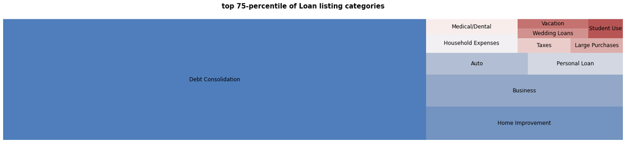

## Prosper Ratings per Loan Status

There is a clear correlation between loan status and Prosper rating. Past due and bad debt loans seem to have a much lower proportion of 'AA' than current and completed loans. Overall, combined ratings between 'D' to 'HR' are significantly more evident in bad debt and past due loan listings.

*The code for the stacked chart below is referenced from Udacity classroom's following* link.

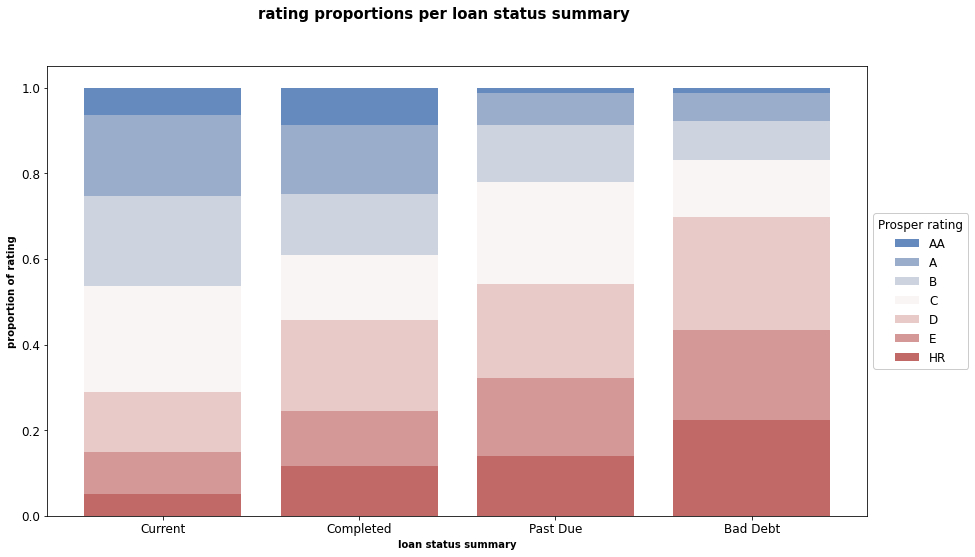

## Average Interest Rates per Prosper Rating

There is a negative trend between Prosper rating and interest rate. This is simply expected considering that high risk ratings are more prone to becoming bad debts and so the cost of borrowing (i.e. interest rate) must be higher to match this high risk.

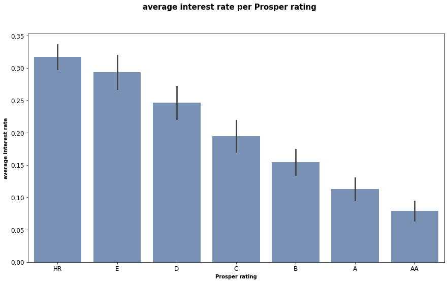

## Interet Rate and Loan Amount per Proper Rating

Two main things can be noticed from the below chart. First, high risk ratings are much more evident in small size loans. Second, for the same level of loan amount, the better the rating of a loan, the lower the borrower rate. This strengthens the relationship between interest rate and Proper ratings even further.

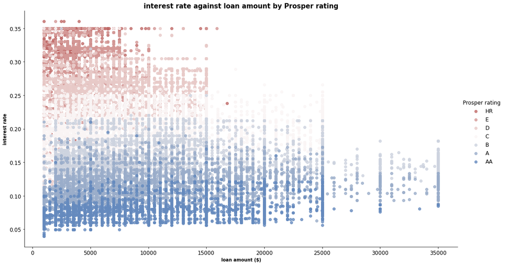

## Trend of Borrowers' Homeownership Status

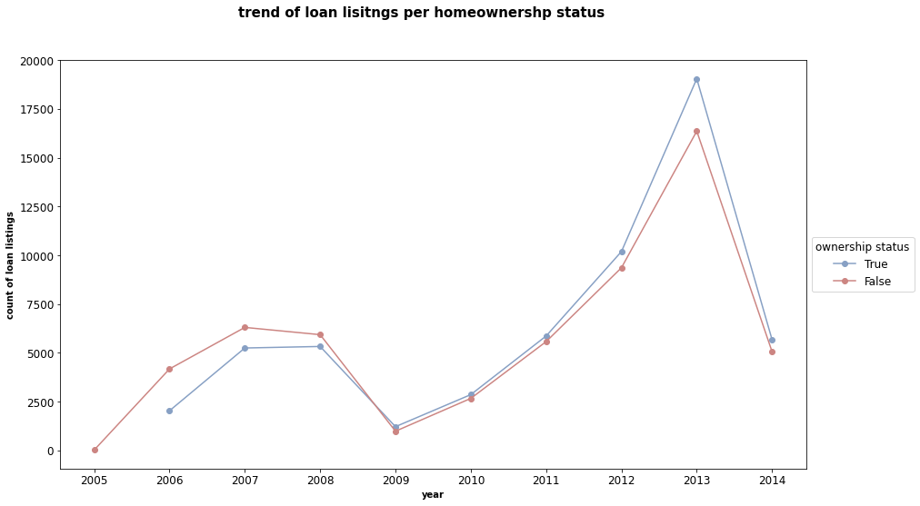